# Predicting Exercise Format in R Using the caret Package

Kairsten Fay

February 25, 2017

## Overview

The Human Activity Recognition (HAR) dataset from UCI is a public domain dataset (1, 2). In recent years, the HAR dataset has enabled researchers around the world to develop machine learning tools to classify physical activity through wearable technology. Here, I classify bicep curls performed by six test subjects by the matter in which they performed the curls; this was categorized by the ‘classe’ variable in the dataset. The forms were the correct curl (A), curling while bringing elbows to the front (B), curling but lifting only halfway (C), curling but lowering only halfway (D), and curling while thrusting the hips forward (E). Of the various regression model approaches used, the random forest ensemble method produced the highest accuracy in predicting bicep curl form. When building the models in this project, I used cross-validation to optimize the parameters and to better fit the training data (3). The work presented here is my own with non-negligible support and guidance from Cheng Juan’s publication on practical machine learning using R, which I incidentally found when browsing Google for examples of cross validation in R (4).

## Downloading and Pre-processing

```r
url1 <- "https://d396qusza40orc.cloudfront.net/predmachlearn/pml-training.csv"
url2 <- "https://d396qusza40orc.cloudfront.net/predmachlearn/pml-testing.csv"
if (!file.exists("training.csv")) {
  download.file(url1, "training.csv")
}
if (!file.exists("testing.csv")) {
  download.file(url2, "testing.csv")
}

WLE <- read.csv("training.csv", na.strings=c("", "NA"))
testing <- read.csv("testing.csv", na.strings=c("", "NA"))

str(WLE, list.len=10) ## cols 1:7 are identifiers and will not be useful in prediction
```

```
## 'data.frame':    19622 obs. of  160 variables:
##  $ X                       : int  1 2 3 4 5 6 7 8 9 10 ...
##  $ user_name               : Factor w/ 6 levels "adelmo","carlitos",..: 2 2 2 2 2 2 2 2 2 2 ...
##  $ raw_timestamp_part_1    : int  1323084231 1323084231 1323084231 1323084232 1323084232 1323084232 1323084232 1323084232 1323084232 1323084232 ...
##  $ raw_timestamp_part_2    : int  788290 808298 820366 120339 196328 304277 368296 440390 484323 484434 ...
##  $ cvtd_timestamp          : Factor w/ 20 levels "02/12/2011 13:32",..: 9 9 9 9 9 9 9 9 9 9 ...
##  $ new_window              : Factor w/ 2 levels "no","yes": 1 1 1 1 1 1 1 1 1 1 ...
##  $ num_window              : int  11 11 11 12 12 12 12 12 12 12 ...
##  $ roll_belt               : num  1.41 1.41 1.42 1.48 1.48 1.45 1.42 1.42 1.43 1.45 ...
##  $ pitch_belt              : num  8.07 8.07 8.07 8.05 8.07 8.06 8.09 8.13 8.16 8.17 ...
##  $ yaw_belt                : num  -94.4 -94.4 -94.4 -94.4 -94.4 -94.4 -94.4 -94.4 -94.4 -94.4 ...
##   [list output truncated]
```

```r
WLE[,8:159] <- lapply(WLE[,8:159], as.numeric) ## convert to numeric
small_WLE <- WLE[,-c(1:7)] ## remove first 7 columns
totalNAs <- is.na(apply(small_WLE[,-153], 2, sum)) ## identify columns with missing values
build <- small_WLE[,!totalNAs] ## exclude columns with missing values
rm(small_WLE, totalNAs) ## clean up the environment
```

## Building the Models

Next, I split the `build` data into `training` and `validation` (for out-of-sample error estimates) sets using the `caret` package. I also loaded the `rpart` and `randomForest` packages that the future models would require for training.

```r
library(caret)
library(rpart); library(randomForest)
inBuild <- createDataPartition(build$classe, p=0.7, list=FALSE)
validation <- build[-inBuild,]; training <- build[inBuild,]
```

Then, I generated my models. I began with the most computationally simple and easiest model to understand: the decision tree.

```r
set.seed(1001)
s0 <- system.time({fit0 <- train(classe~., data=training, method="rpart")})[3] ## decision tree
pred0 <- predict(fit0, validation)
cm0 <- confusionMatrix(pred0, validation$classe)[2:3]
print(cm0)
```

```
## $table
##           Reference
## Prediction    A    B    C    D    E
##          A 1517  496  473  429  155
##          B   33  383   35  165  143
##          C  119  260  518  370  302
##          D    0    0    0    0    0
##          E    5    0    0    0  482
##
## $overall
##       Accuracy          Kappa  AccuracyLower  AccuracyUpper   AccuracyNull
##   4.927782e-01   3.369250e-01   4.799263e-01   5.056373e-01   2.844520e-01
## AccuracyPValue  McnemarPValue
##  1.832826e-248            NaN
```

```r
print(s0)
```

```
## elapsed
##  15.285
```

Next, I generated a random forest algorithm also using the `caret` package. My machine had 32 cores, so I was able to run the following tasks in parallel using the `doParallel` package (5).

```r
library(doParallel)
cl <- makeCluster(detectCores())
print(cl)
```

```
## socket cluster with 32 nodes on host 'localhost'
```

```r
registerDoParallel(cl)
set.seed(1001)
s1 <- system.time({fit1 <- train(classe~., data=training, method="rf", allowParallel=TRUE)})[3] ## random forest
stopCluster(cl)
pred1 <- predict(fit1, validation)
cm1 <- confusionMatrix(pred1, validation$classe)[2:3]
print(cm1)
```

```
## $table
##           Reference
## Prediction    A    B    C    D    E
##          A 1673    6    0    0    0
##          B    1 1131    9    0    0
##          C    0    2 1016   22    0
##          D    0    0    1  941    4
##          E    0    0    0    1 1078
##
## $overall
##       Accuracy          Kappa  AccuracyLower  AccuracyUpper   AccuracyNull
##      0.9921835      0.9901116      0.9895875      0.9942718      0.2844520
## AccuracyPValue  McnemarPValue
##      0.0000000            NaN
```

```r
print(s1)
```

```
## elapsed
## 327.909
```

While this method is extremely accurate, correctly predicting the classe variable with 99% accuracy, it was computationally expensive. Using 32 cores, it still took 328 seconds to train. In machine learning, there is a tradeoff between computational expense and model accuracy. To reduce the amount of time spent training, I re-ran the model using 3-fold cross validation (4, 6).

```r
cl <- makeCluster(detectCores())
registerDoParallel(cl)
set.seed(1001)
s1.1 <- system.time({fit1.1 <- train(classe~., data=training, method="rf", allowParallel=TRUE,
                trControl = trainControl(method="cv", number=3))})[3] ## rf with 3-fold CV
stopCluster(cl)
pred1.1 <- predict(fit1.1, validation)
cm1.1 <- confusionMatrix(pred1.1, validation$classe)[2:3]
print(cm1.1)
```

```
## $table
##           Reference
## Prediction    A    B    C    D    E
##          A 1672    5    0    0    1
##          B    2 1130    7    1    2
##          C    0    3 1016   17    2
##          D    0    1    3  945    5
##          E    0    0    0    1 1072
##
## $overall
##       Accuracy          Kappa  AccuracyLower  AccuracyUpper   AccuracyNull
##      0.9915038      0.9892523      0.9888140      0.9936876      0.2844520
## AccuracyPValue  McnemarPValue
##      0.0000000            NaN
```

```r
print(s1.1)
```

```
## elapsed
##  99.045
```

By cutting the size of the training data through 3-fold cross-validation, my time to train decreased super-linearly from 328 to 99 seconds (70% reduction). The trade-off was a 0.07% decrease in accuracy. I plotted the model’s converged error to determine the optimum number of trees to train.

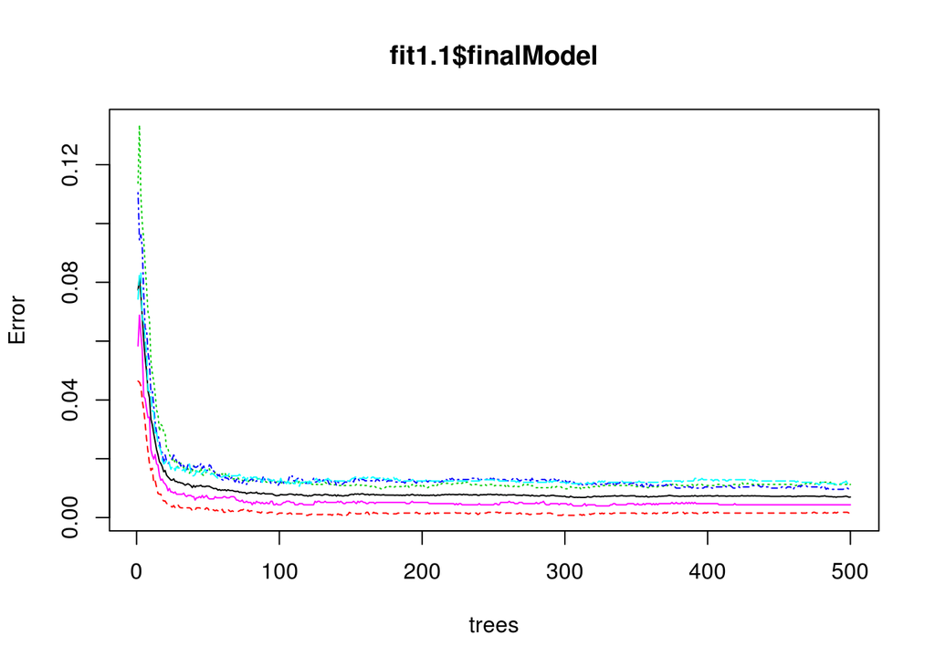

```r
plot(fit1.1$finalModel)
```

The overall error for `fit1.1` converged at around 100 trees (4). I tuned my number of trees to 100 for a third random forest model, `fit1.2`, to generate a faster algorithm.

```r
cl <- makeCluster(detectCores())
registerDoParallel(cl)
set.seed(1001)
s1.2 <- system.time({fit1.2 <- train(classe~., data=training, method="rf", allowParallel=TRUE,
                ntree = 100, trControl = trainControl(method="cv", number=3))})[3] ## rf, 3-fold CV, 100 trees
stopCluster(cl)
pred1.2 <- predict(fit1.2, validation)
cm1.2 <- confusionMatrix(pred1.2, validation$classe)[2:3]
print(cm1.2)
```

```
## $table
##           Reference
## Prediction    A    B    C    D    E
##          A 1672    7    0    0    0
##          B    1 1132    3    1    0
##          C    1    0 1022   17    4
##          D    0    0    1  946    7
##          E    0    0    0    0 1071
##
## $overall
##       Accuracy          Kappa  AccuracyLower  AccuracyUpper   AccuracyNull
##      0.9928632      0.9909719      0.9903653      0.9948517      0.2844520
## AccuracyPValue  McnemarPValue
##      0.0000000            NaN
```

```r
print(s1.2)
```

```
## elapsed
##  26.325
```

The tuned random forest model with cross-validation performed with an out-of-sample accuracy of 99% and only took 26 seconds to train.

Next, I explored meta-algorithms by creating a boosting algorithm with 3-fold cross-validation.

```r
cl <- makeCluster(detectCores())
registerDoParallel(cl)
set.seed(100)
s2 <- system.time({fit2 <- train(classe~., data=training, method="gbm", verbose=FALSE,
                                 trControl=trainControl(method="cv", number=3))})[3] ## boosting with 3-fold CV
stopCluster(cl)
pred2 <- predict(fit2, validation)
cm2 <- confusionMatrix(pred2, validation$classe)[2:3]
print(cm2)
```

```
## $table
##           Reference
## Prediction    A    B    C    D    E
##          A 1645   33    0    1    3
##          B   25 1080   35    4   14
##          C    2   23  978   35   15
##          D    2    2   12  920   22
##          E    0    1    1    4 1028
##
## $overall
##       Accuracy          Kappa  AccuracyLower  AccuracyUpper   AccuracyNull
##   9.602379e-01   9.496970e-01   9.549273e-01   9.650858e-01   2.844520e-01
## AccuracyPValue  McnemarPValue
##   0.000000e+00   1.440974e-08
```

```r
print(s2)
```

```
## elapsed
##  54.211
```

The model generated 96% out-of-sample accuracy and trained in 54 seconds.

Finally, I generated a bagging algorithm to predict the `classe` variable.

```r
cl <- makeCluster(detectCores())
registerDoParallel(cl)
set.seed(1001)
s3 <- system.time({fit3 <- train(classe~., data=training, method="treebag")})[3] ## bagging
stopCluster(cl)
pred3 <- predict(fit3, validation)
cm3 <- confusionMatrix(pred3, validation$classe)[2:3]
print(cm3)
```

```
## $table
##           Reference
## Prediction    A    B    C    D    E
##          A 1669    5    0    0    1
##          B    3 1120    8    1    3
##          C    0    8 1012   21    3
##          D    1    4    6  942    2
##          E    1    2    0    0 1073
##
## $overall
##       Accuracy          Kappa  AccuracyLower  AccuracyUpper   AccuracyNull
##      0.9882753      0.9851696      0.9851848      0.9908663      0.2844520
## AccuracyPValue  McnemarPValue
##      0.0000000            NaN
```

```r
print(s3)
```

```
## elapsed
##  50.488
```

The bagging model had 99% accuracy out-of-sample and trained in 50 seconds in parallel.

## Model Evaluation

```r
eval <- data.frame(tree=cm0$overall[1], rf=cm1$overall[1], rfcv=cm1.1$overall[1],
                   rfcv100=cm1.2$overall[1], boost=cm2$overall[1], bag=cm3$overall[1])
time <- data.frame(tree=s0, rf=s1, rfcv=s1.1, rfcv100=s1.2, boost=s2, bag=s3)
res <- rbind(eval, time)
print(res)
```

```
##                tree          rf       rfcv    rfcv100      boost
## Accuracy  0.4927782   0.9921835  0.9915038  0.9928632  0.9602379
## elapsed  15.2850000 327.9090000 99.0450000 26.3250000 54.2110000
##                 bag
## Accuracy  0.9882753
## elapsed  50.4880000
```

I plotted the top ten most important variables from the rfcv100 model. Then, I viewed the final model and plotted its cross-validation graph and its error convergence.

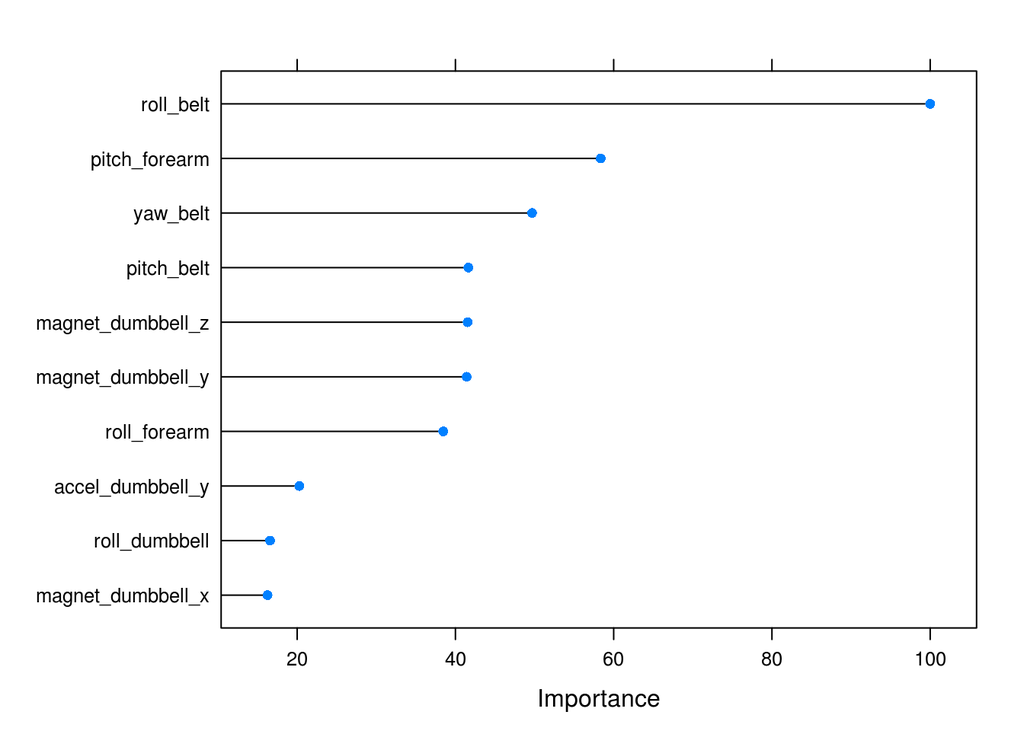

```r
plot(varImp(fit1.2), top=10)
```

```r
fit1.2$finalModel
```

```
##
## Call:
##  randomForest(x = x, y = y, ntree = 100, mtry = param$mtry, allowParallel = TRUE)
##                Type of random forest: classification
##                      Number of trees: 100
## No. of variables tried at each split: 27
##
##         OOB estimate of  error rate: 0.79%
## Confusion matrix:
##      A    B    C    D    E class.error
## A 3899    6    0    0    1 0.001792115
## B   25 2623    9    0    1 0.013167795
## C    0   16 2369   11    0 0.011268781
## D    0    2   22 2225    3 0.011989343
## E    0    2    4    7 2512 0.005148515
```

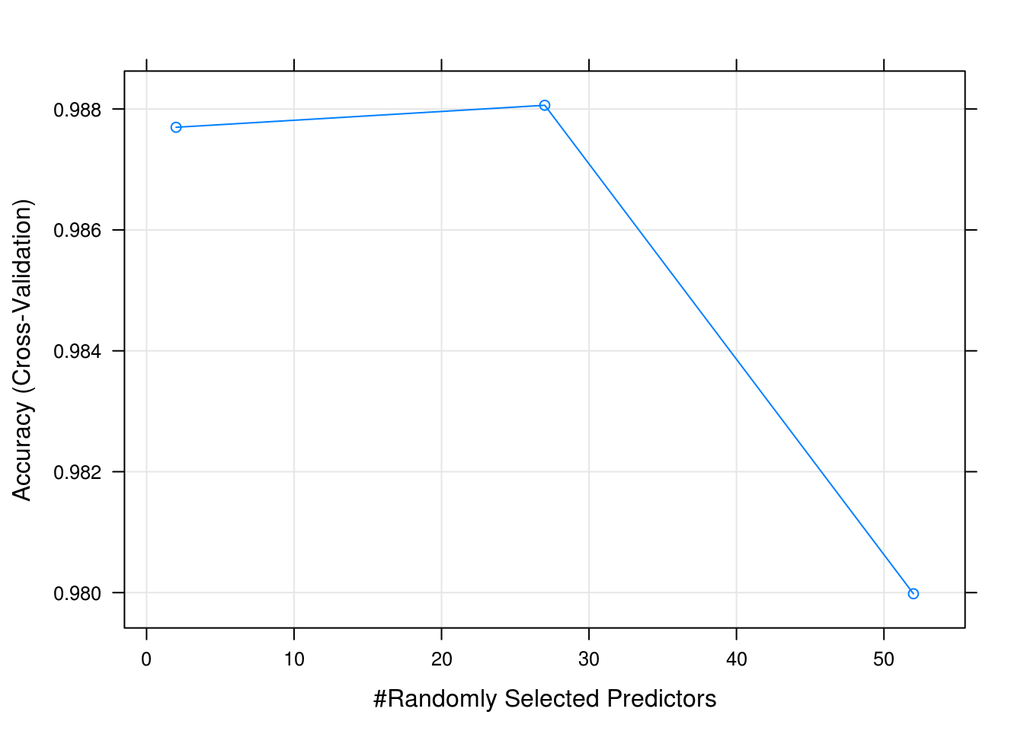

```r
plot(fit1.2)
```

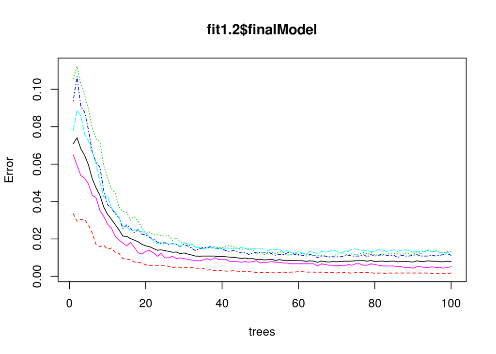

```r
plot(fit1.2$finalModel)
```

The optimum number of predictors in rfcv100 was 27. Using more or less than 27 predictors resulted in a decrease in accuracy. Additionally, the error convergence plot suggests that even fewer trees could be used to train the model to result in increased computational efficiency.

## Works cited

[1] Human Activity Recognition (HAR) database. Retrieved from http://groupware.les.inf.puc-rio.br/har on 8 February 2017.

[2] Ugulino et al. 2012. Wearable Computing: Accelerometers’ Data Classification of Body Postures and Movements. Proceedings of the 21st Brazilian Symposium on Artificial Intelligence. Advances in Artificial Intelligence - SBIA 2012. In: Lecture Notes in Computer Science. , pp. 52-61. Curitiba, PR: Springer Berlin / Heidelberg, 2012. ISBN 978-3-642-34458-9. DOI: 10.1007/978-3-642-34459-6_6.

[3] Cross-validation (statistics). Retrieved from https://en.wikipedia.org/wiki/Cross-validation_(statistics) on 25 February 2017.

[4] Juan C. 2015. An example of practical machine learning using R. Retrieved from https://rstudio-pubs-static.s3.amazonaws.com/64455_df98186f15a64e0ba37177de8b4191fa.html on 8 February 2017.

[5] Shaikh S. 2015. Parallelize machine learning in R with multi-core CPUs. Retrieved from http://sshaikh.org/2015/05/06/parallelize-machine-learning-in-r-with-multi-core-cpus/ on 25 February 2017.

[6] Tepper P. 2013. What is in general time complexity of random forest?… Retrieved from https://www.quora.com/What-is-in-general-time-complexity-of-random-forest-What-are-the-important-parameters-that-affect-this-complexity on 25 February 2017.